# Lesson 4

### Scatterplots and Perceived Audience Size

Notes:

### Scatterplots

Notes:

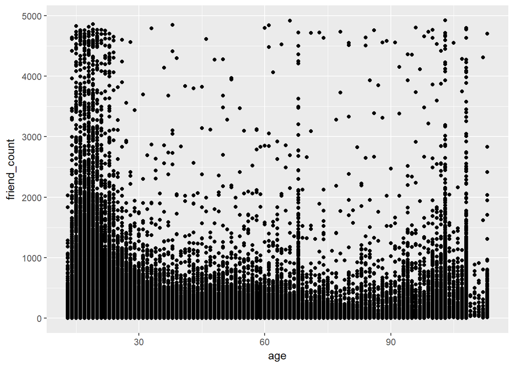

```r
library(ggplot2)
pf <- read.csv('pseudo_facebook.tsv', sep = '\t')

ggplot(aes(x = age, y = friend_count), data = pf) +
  geom_point()
```

#### What are some things that you notice right away?

Response:

All of the data points are grouped into vertical lines and that the younger the age the more likely they are to have more friends.

### ggplot Syntax

Notes:

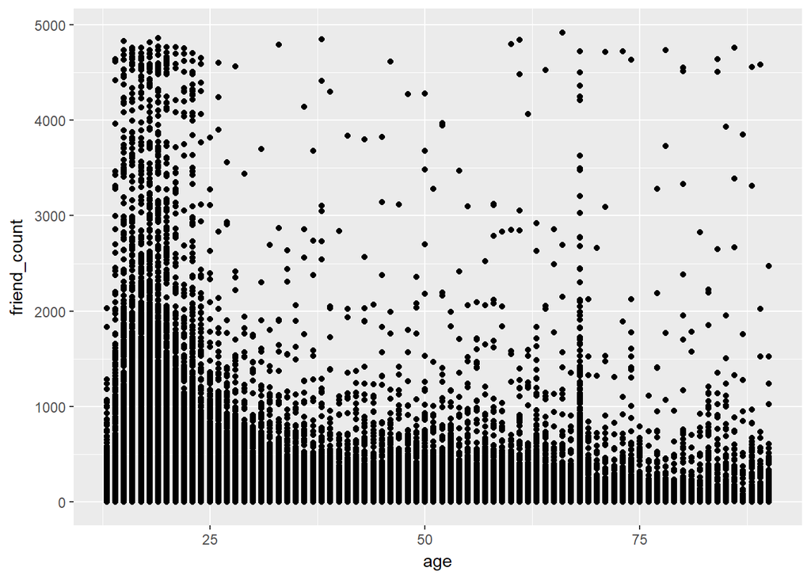

```r
ggplot(aes(x = age, y = friend_count), data = pf) +
  geom_point() +
  xlim(13, 90)
```

```r
summary(pf$age)
```

```
##    Min. 1st Qu.  Median    Mean 3rd Qu.    Max.
##   13.00   20.00   28.00   37.28   50.00  113.00
```

Build one layer at a time to find errors easier

### Overplotting

Notes:

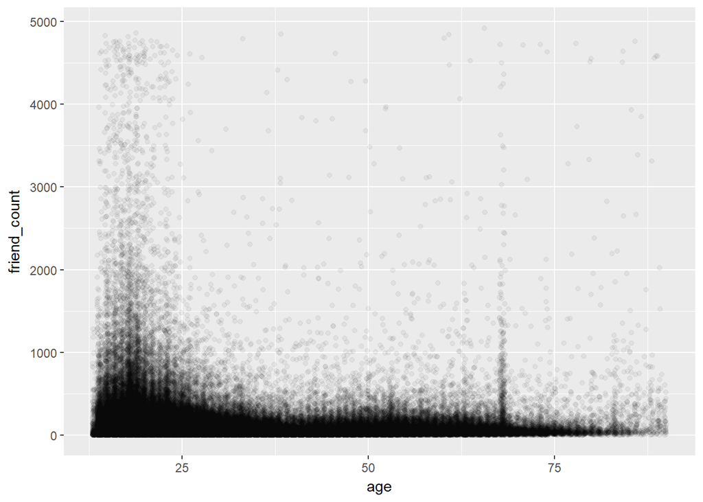

```r
ggplot(aes(x = age, y = friend_count), data = pf) +
  geom_jitter(alpha = 1/20) +
  xlim(13, 90)
```

#### What do you notice in the plot?

Response:

The bar for 69 is still clearly visible and it is more obvious that the number generally decreases as the age increases.

### Coord_trans()

Notes:

#### Look up the documentation for coord_trans() and add a layer to the plot that transforms friend_count using the square root function. Create your plot!

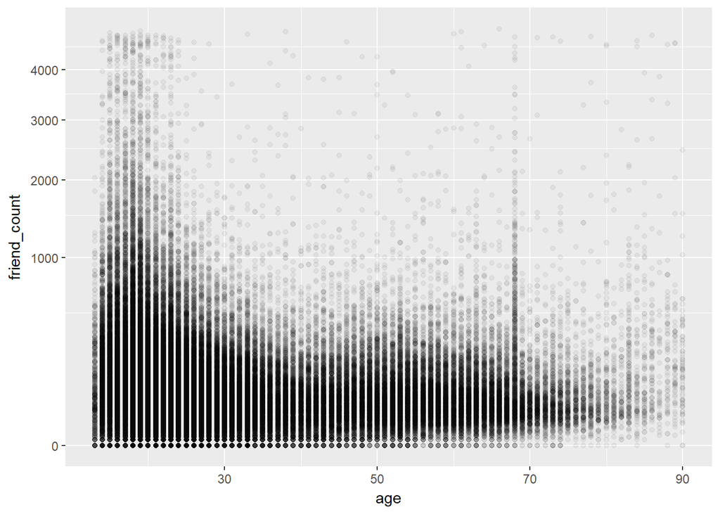

```r
ggplot(aes(x = age, y = friend_count), data = pf) +
  geom_point(alpha = 1/20) +
  xlim(13, 90) +
  coord_trans(y = "sqrt")
```

#### What do you notice?

First off coord_trans does not work with geom_jitter, second the datapoints near the bottom are more spread out vertically to present them as more of a focus.

To use jitter you need more advanced syntax to only jitter the ages, also to prevent possible negatives if 0 is jittered. To do this in `geom_point()` pass `position = position_jitter(h = 0)`

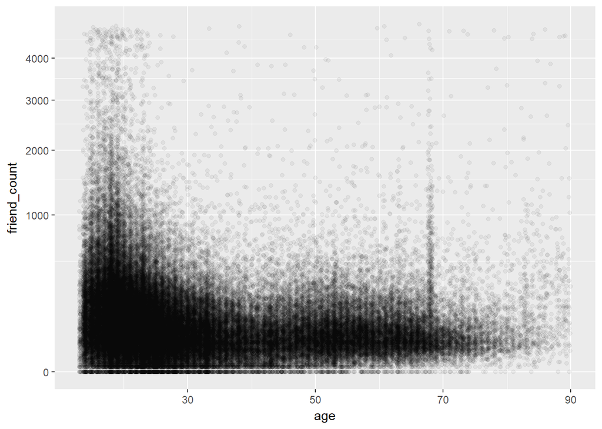

```r
ggplot(aes(x = age, y = friend_count), data = pf) +
  geom_point(alpha = 1/20, position = position_jitter(h = 0)) +
  xlim(13, 90) +
  coord_trans(y = "sqrt")
```

### Alpha and Jitter

Notes:

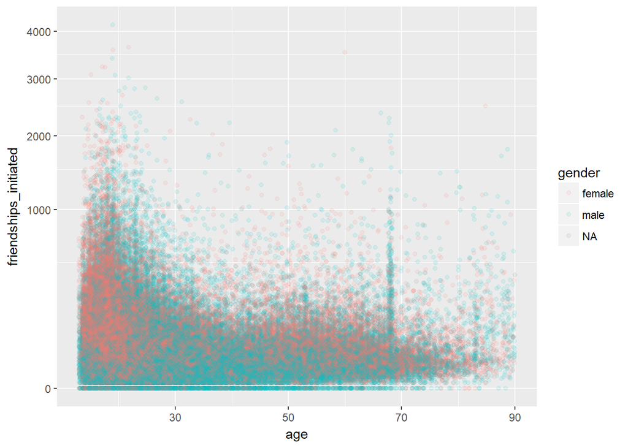

```r
ggplot(aes(x = age, y = friendships_initiated, color = gender), data = pf) +
  geom_point(alpha = 1/10, position = position_jitter(h = 0)) +
  xlim(13, 90) +
  coord_trans(y = "sqrt")
```

### Overplotting and Domain Knowledge

Notes:

plotting as a percentage of the whole

### Conditional Means

Notes:

```r
library(dplyr)
```

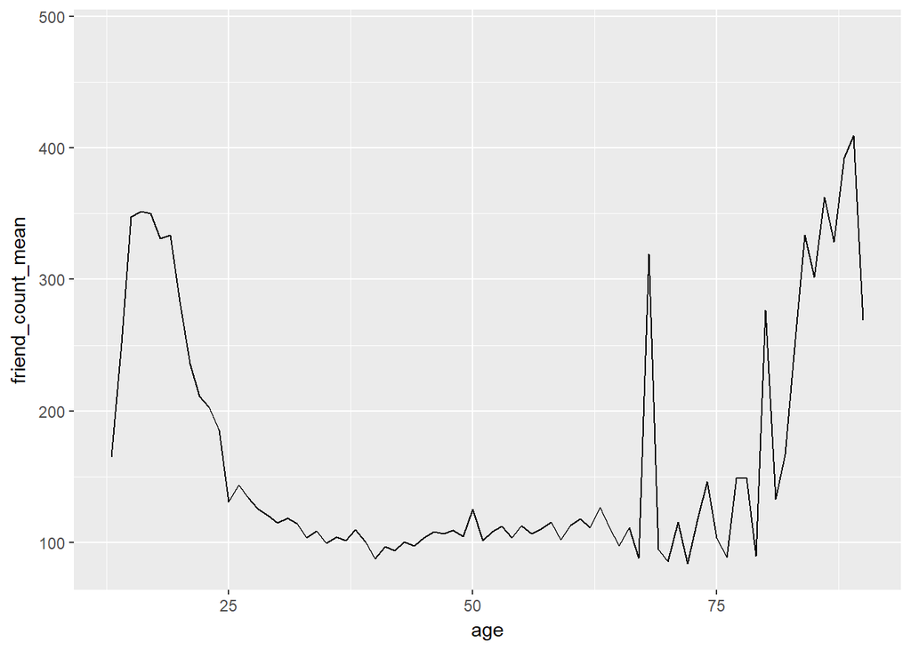

```r
age_groups <- group_by(pf, age)
pf.fc_by_age <- summarise(age_groups,
          friend_count_mean = mean(friend_count),
          friend_count_median = median(friend_count),
          n = n())
pf.fc_by_age <- arrange(pf.fc_by_age, age)

ggplot(aes(x = age, y = friend_count_mean), data = pf.fc_by_age) +
  geom_line() +
  xlim(13,90)
```

### Overlaying Summaries with Raw Data

Notes:

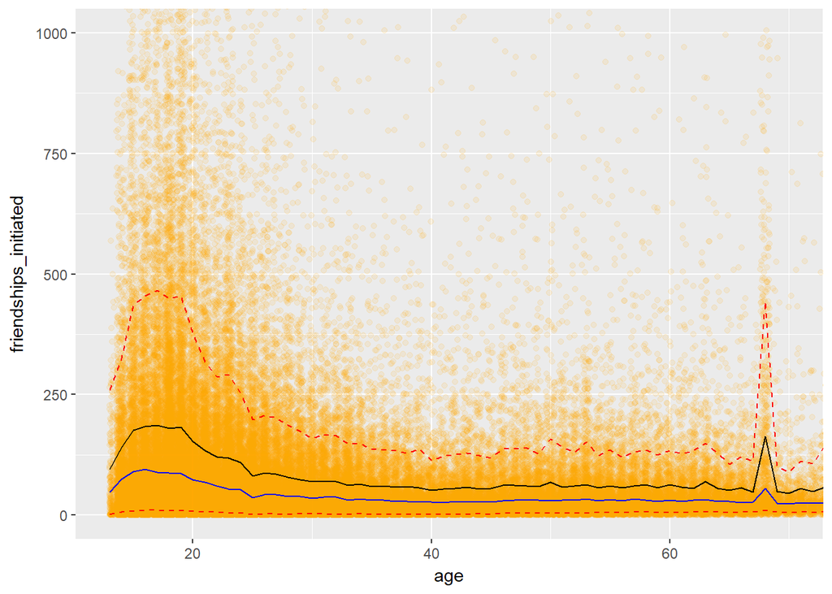

```r
ggplot(aes(x = age, y = friendships_initiated), data = pf) +
  geom_point(alpha = 1/10, position = position_jitter(h = 0), color = 'orange') +
  xlim(13, 90) +
  coord_trans(y = "sqrt") +
  geom_line(stat = 'summary', fun.y = mean) +
  geom_line(stat = 'summary', fun.y = median, color = 'blue') +
  geom_line(stat = 'summary', fun.y = quantile, fun.args = list(probs = 0.1), color = 'red', linetype = 2) +
  geom_line(stat = 'summary', fun.y = quantile, fun.args = list(probs = 0.9), color = 'red', linetype = 2) +
  coord_cartesian(xlim = c(13,70), ylim = c(0,1000))
```

#### What are some of your observations of the plot?

Response:

I notice that the median is always lower than the mean and that the median is closer to the center of the main body of datapoints. It appears that the data is long tailed towards the high friend counts which pulls the mean upwards.

### Moira: Histogram Summary and Scatterplot

See the Instructor Notes of this video to download Moira’s paper on perceived audience size and to see the final plot.

Notes:

### Correlation

Notes:

```r
cor.test(pf$age, pf$friend_count)
```

```
##
##  Pearson's product-moment correlation
##
## data:  pf$age and pf$friend_count
## t = -8.6268, df = 99001, p-value < 2.2e-16
## alternative hypothesis: true correlation is not equal to 0
## 95 percent confidence interval:
##  -0.03363072 -0.02118189
## sample estimates:
##         cor
## -0.02740737
```

Look up the documentation for the cor.test function.

What’s the correlation between age and friend count? Round to three decimal places. Response:

-0.027

### Correlation on Subsets

Notes:

```r
with(pf[pf$age <= 70,], cor.test(age, friend_count))
```

```
##
##  Pearson's product-moment correlation
##
## data:  age and friend_count
## t = -52.592, df = 91029, p-value < 2.2e-16
## alternative hypothesis: true correlation is not equal to 0
## 95 percent confidence interval:
##  -0.1780220 -0.1654129
## sample estimates:
##        cor
## -0.1717245
```

### Correlation Methods

Notes:

http://www.statisticssolutions.com/correlation-pearson-kendall-spearman/

## Create Scatterplots

Notes:

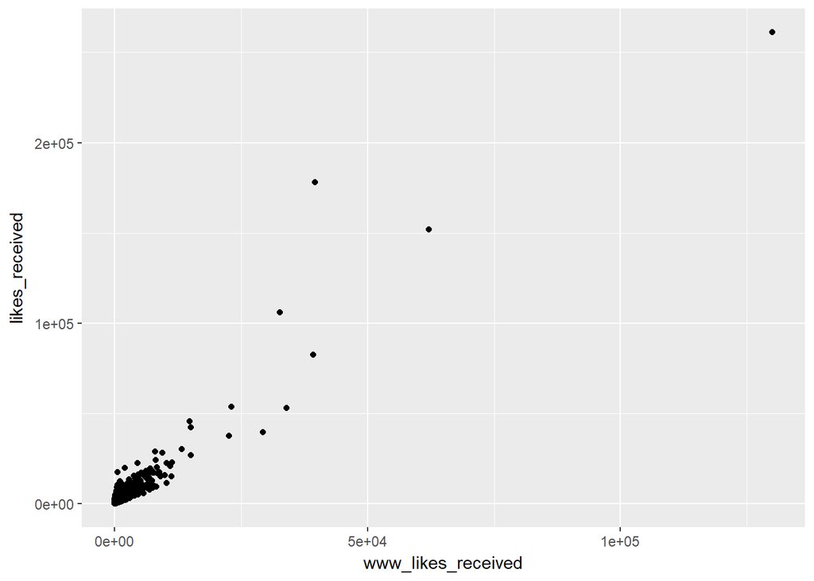

```r
library(ggplot2)
ggplot(aes(x = www_likes_received, y = likes_received), data = pf) +
  geom_point()#alpha = 1/20, position = position_jitter(h = 0)) +
```

```r
  #xlim(13, 90) +
  #coord_trans(y = "sqrt")
```

### Strong Correlations

Notes:

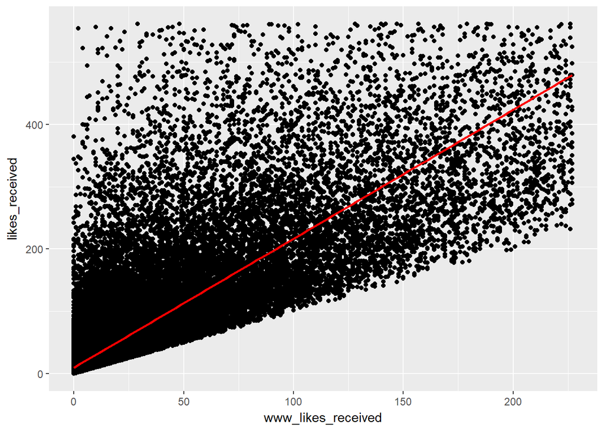

```r
ggplot(aes(x = www_likes_received, y = likes_received), data = pf) +
  geom_point() +
  xlim(0, quantile(pf$www_likes_received, 0.95)) +
  ylim(0, quantile(pf$likes_received, 0.95)) +
  geom_smooth(method = 'lm', color = 'red')
```

What’s the correlation betwen the two variables? Include the top 5% of values for the variable in the calculation and round to 3 decimal places.

```r
with(pf, cor.test(www_likes_received, likes_received))
```

```
##
##  Pearson's product-moment correlation
##
## data:  www_likes_received and likes_received
## t = 937.1, df = 99001, p-value < 2.2e-16
## alternative hypothesis: true correlation is not equal to 0
## 95 percent confidence interval:
##  0.9473553 0.9486176
## sample estimates:
##       cor
## 0.9479902
```

Response:

0.948 Variable is a superset of another